# Activity: Street or Road?

Matthew Beckman

# Assignment Remarks:

Two data sets are provided. One includes 15,000 street addresses of registered voters in Wake County, North Carolina. The other includes over 900,000 street addresses of Medicare Service Providers. You are expected to use BOTH data sets during the activity.

# Activity

People’s addresses involve streets, lanes, courts, avenues, and so on. How many such road-related words are in common use?

In general, the steps to automate this sort of task might be summarized as follows:

1. In everyday language, describe a patter that you think will identify the information that you’re looking for
2. Translate (1) into a regular expression
3. Filter to retain the cases that match the expression… hint: `filter()` and `grepl()` are useful for this
4. Filter to retain the cases that do not match the expression
5. Examine the results of (3) and (4) to identify shortcomings in your pattern matching algorithm
6. Improve or extend the pattern to deal with the mistaken cases
7. Repeat (1) through (6) until satisfied
8. Put extraction parenthesis around the parts of the regular expression that contain the information you want

### Resources

```r
# 15000 street addresses of registered voters in Wake County, North Carolina
AddressesVoters <- read_csv("https://mdbeckman.github.io/dcSupplement/data/street-addresses.csv")
# AddressesVoters <- read_csv("street-addresses.csv")    # local copy

# 900,000 street addresses of Medicare Service Providers
download.file(url = "https://mdbeckman.github.io/dcSupplement/data/CMS_ProvidersSimple.rds",
              destfile = "CMS_ProvidersSimple.rds")
AddressesMSP <- readRDS("CMS_ProvidersSimple.rds")
```

```r
# matching addresses
inner_join(AddressesMSP, AddressesVoters) %>% glimpse()
```

```
Rows: 131
Columns: 3
$ address    <chr> "101 STADIUM DR", "1821 HILLANDALE RD", "101 MAYWOOD AVE", "101 STADIUM DR", …
$ first_name <chr> "SARAH", "ERIC", "JOSEPH", "BARBARA", "MICHEL", "", "MARIA", "REBECCA", "AMAN…
$ sex        <chr> "F", "M", "M", "F", "M", "", "F", "F", "F", "M", "F", "F", "F", "F", "F", "",…
```

```r
# combine sources
AddressesVoters <-
  AddressesVoters %>%
  mutate(source = "Wake County Voters")

AddressesMSP <-
  AddressesMSP %>%
  mutate(source = "Medicare Service Providers")


AddressesTotal <- bind_rows(AddressesVoters, AddressesMSP)

head(AddressesTotal)
```

| address | source | first_name | sex |
| --- | --- | --- | --- |
| 2117 MARINER CIRCLE | Wake County Voters | NA | NA |
| 101 EPPING WAY | Wake County Voters | NA | NA |
| PO BOX 58592 | Wake County Voters | NA | NA |
| 5102 ECHO RIDGE RD | Wake County Voters | NA | NA |
| PO BOX 37218 | Wake County Voters | NA | NA |
| PO BOX 37218 | Wake County Voters | NA | NA |

```r
tail(AddressesTotal)
```

| address | source | first_name | sex |
| --- | --- | --- | --- |
| 19735 GERMANTOWN RD | Medicare Service Providers | INDIRA | F |
| 195 PEABODY ST | Medicare Service Providers | JENNY | F |
| 1355 FOUR MILE DR | Medicare Service Providers | NORMAN | M |
| 1410 OAK ST | Medicare Service Providers |  |  |
| 1100 9TH AVE | Medicare Service Providers | GEOFFREY | M |
| 8260 ATLEE RD | Medicare Service Providers | GABRIELLA | F |

```r
NA
```

### Solved Example

Suppose we want to extract the PO Box number from addresses of the registered voters in Wake County, North Carolina.

```r
# the address data
Addresses <- read_csv("https://mdbeckman.github.io/dcSupplement/data/street-addresses.csv")
# sample a few dozen cases
Sample <-
  Addresses %>%
  sample_n(size = 50)
```

1. The PO Box cases tend to have a substring “PO”
2. the regular expression for “PO” is simply `"PO"`
3. Find some cases that match:

```r
Matches <-
  Sample %>%
  filter(grepl("PO", address))
```

4. Find some cases that don’t match:

```r
Dont <-
  Sample %>%
  filter( !grepl("PO", address))
```

5. Find cases of `Matches` that we don’t want to match, and find cases of `Dont` that we should have matched.

```r
# Inspect Matches
head(Matches)
```

| address |
| --- |
| PO BOX 72 |
| PO BOX 642 |
| PO BOX 614 |
| PO BOX 765 |
| PO BOX 831 |
| PO BOX 2344 |

```r
# Inspect Dont
head(Dont)
```

| address |
| --- |
| 102 DUDEN CT APT G |
| 2915 GRETMAR |
| P O BOX 1104 |
| 2506 KING ARTHUR DRIVE |
| NCSU BOX 16134 |
| 368 CP STEWART ROAD |

6. Maybe “BOX” might be a better pattern, so we’ll try that instead.

```r
# Pattern to locate
pattern <- "BOX\\s+(\\d+)"

# Inspect Matches
Matches <-
  Sample %>%
  filter(grepl(pattern, address))

Matches
```

| address |
| --- |
| PO BOX 72 |
| P O BOX 1104 |
| PO BOX 642 |
| PO BOX 614 |
| PO BOX 765 |
| NCSU BOX 16134 |
| PO BOX 831 |
| PO BOX 2344 |
| PO BOX 1535 |
| PO BOX 33126 |

[output cut: 26 more lines]

```r
# Inspect Dont
Dont <-
  Sample %>%
  filter( !grepl(pattern, address))

Dont
```

| address |
| --- |
| 102 DUDEN CT APT G |
| 2915 GRETMAR |
| 2506 KING ARTHUR DRIVE |
| 368 CP STEWART ROAD |
| 114 EAST MCIVER STREET |
| 913 N ARENDELL AVE |
| 9650 STRICKLAND RD UNIT 103 |
| DOROTHEA DIX HOSPITAL |
| 3308 BARWELL RD |
| 341 GILMAN LN |

[output cut: 4 more lines]

We’ll now use `tidyr::extract()` to pull the part of the pattern identified by the extraction parenthesis.

```r
BoxNumbers <-
  Sample %>%
  filter(grepl(pattern, address)) %>%
  tidyr::extract(address, into = "boxnum", regex = pattern)

head(BoxNumbers, 10)
```

| boxnum |
| --- |
| 72 |
| 1104 |
| 642 |
| 614 |
| 765 |
| 16134 |
| 831 |
| 2344 |
| 1535 |
| 33126 |

### Back to the Streets

We’ll go line-by-line explaining the following code chunk:

```
pattern <- "(ST|RD|ROAD)"

LeftOvers <-
  Addresses %>%
  filter( ! grepl(pattern, address),
          ! grepl("\\sAPT|UNIT\\s[\\d]+$", address),
          ! grepl("BOX|BX", address))
```

This is the regular expression we want to extract (e.g. ST, RD, ROAD):

```
pattern <- "(ST|RD|ROAD)"
```

Assign all remaining non-matches to data set called called `LeftOvers`:

```
LeftOvers <-
```

Start with the `Addresses` data set:

```
  Addresses %>%
```

Remove the cases that we want to match:

```
  filter( ! grepl(pattern, address),
```

Remove some known cases (apartments, etc) that we know we don’t want:

```
          ! grepl("\\sAPT|UNIT\\s[\\d]+$", address),
```

Remove some more known cases (PO Boxes) that we know we don’t want:

```
          ! grepl("BOX|BX", address))
```

Here’s the whole thing together:

```r
pattern <- "(ST|RD|ROAD)"

LeftOvers <-
  AddressesTotal %>%
  filter( !grepl(pattern, address),
          !grepl("\\sAPT|UNIT\\s[\\d]+$", address),
          !grepl("BOX|BX", address))

# Inspect the result
head(LeftOvers, 10)
```

| address | source | first_name | sex |
| --- | --- | --- | --- |
| 2117 MARINER CIRCLE | Wake County Voters | NA | NA |
| 101 EPPING WAY | Wake County Voters | NA | NA |
| 04-I ROBIN CIRCLE | Wake County Voters | NA | NA |
| NCSU B0X 15637 | Wake County Voters | NA | NA |
| 4719 BROWN TRAIL | Wake County Voters | NA | NA |
| 130 THE WINERY | Wake County Voters | NA | NA |
| 5250 ADAMS AVE | Wake County Voters | NA | NA |
| 7416 IVY LEAGUE LN | Wake County Voters | NA | NA |
| 12629 WATERMAN DR | Wake County Voters | NA | NA |
| HMIA-267 | Wake County Voters | NA | NA |

### Your Turn: Explain your method & present result (use `ggplot()`)

Iterate the method to select more of the desired street & road identifiers.

```r
# regular expression we want to extract including several different street & road abbreviations
pattern <- "(AVENUE|AVE|BLVD|BLV|CIRCLE|CIR|COURT|CT|DRIVE|DR|LN|LANE|LOOP|PATH|PL|PLACE|PKWY|RD|ROAD|RUN|ST|STREET|TERRACE|TRAIL|WAY)"

LeftOvers <-               # reduced data set of non-matches will be called `LeftOvers`
  AddressesTotal %>%            # start with all the addresses
  filter( !grepl(pattern, address),                    # remove the current pattern we like
          !grepl("\\sAPT|UNIT\\s[\\d]+$", address),    # remove APT & UNIT addresses we don't want
          !grepl("BOX|BX", address),                   # remove PO BOX addresses we don't want
          !grepl("HALL", address))                     # remove HALL addresses we don't want

head(LeftOvers, 30)            # inspect the LeftOvers data
```

| address | source | first_name | sex |
| --- | --- | --- | --- |
| NCSU B0X 15637 | Wake County Voters | NA | NA |
| 130 THE WINERY | Wake County Voters | NA | NA |
| HMIA-267 | Wake County Voters | NA | NA |
| 311 BAREFOOT | Wake County Voters | NA | NA |
| 512 LIVE OAK | Wake County Voters | NA | NA |
| 1706 WINGATE UNIVERSITY | Wake County Voters | NA | NA |
| AT BN BRAVO CO | Wake County Voters | NA | NA |
| UR 6516 | Wake County Voters | NA | NA |
| 104 SILVERWOOD POINT | Wake County Voters | NA | NA |
| PMB 387 6325-9 FALLS OF NEUSE | Wake County Voters | NA | NA |

[output cut: 20 more lines]

Now that we’ve reached a point where there isn’t too much of value left in the sample of `LeftOvers` from the `Address` data, we’ll stop here. Next, we filter to just include the matches that we want, and then show the results as a sorted table and a plot for each address source.

*remarks comparing and contrasting the distribution associated with each source will vary–depending in part on the specific street endings included in the analysis.*

```r
# regular expression we want to extract including several different street & road abbreviations
pattern <- "(AVENUE|AVE|BLVD|BLV|CIRCLE|CIR|COURT|CT|DRIVE|DR|LN|LANE|LOOP|PATH|PL|PLACE|PKWY|RD|ROAD|RUN|ST|STREET|TERRACE|TRAIL|WAY)"

# Set of matches extracted
RoadNames <-
  AddressesTotal %>%
  filter(grepl(pattern, address)) %>%
  tidyr::extract(address, into = "name", regex = pattern)

# frequency table
RoadNameFrequency <-
  RoadNames %>%
  group_by(name, source) %>%
  summarise(count = n()) %>%
  mutate(name = reorder(name, desc(count))) %>%
  arrange(desc(count))
```

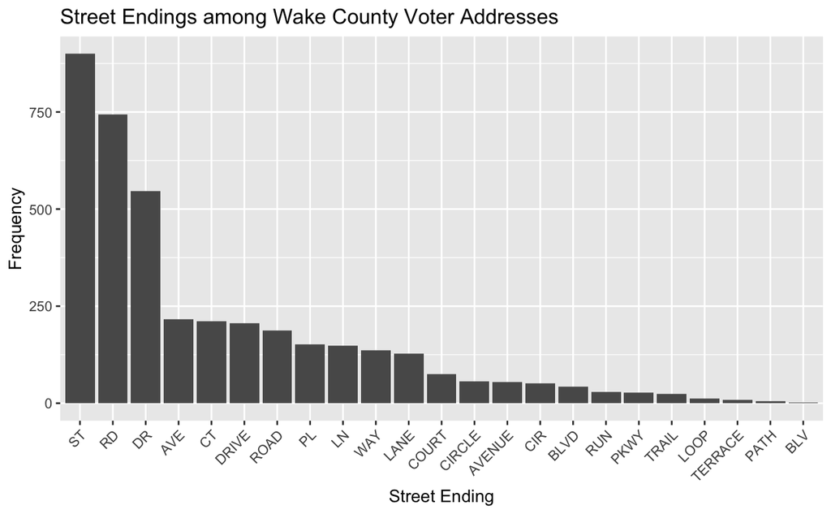

```r
# Bar chart of frequency
RoadNameFrequency %>%
  filter(grepl(pattern = "Voter", x = source)) %>%
  ggplot(aes(x = reorder(name, desc(count)), y = count)) +
  geom_bar(stat = "identity") +
  theme(axis.text.x = element_text(angle = 45, hjust = 1)) +
  ggtitle("Street Endings among Wake County Voter Addresses") +
  xlab("Street Ending") +
  ylab("Frequency")
```

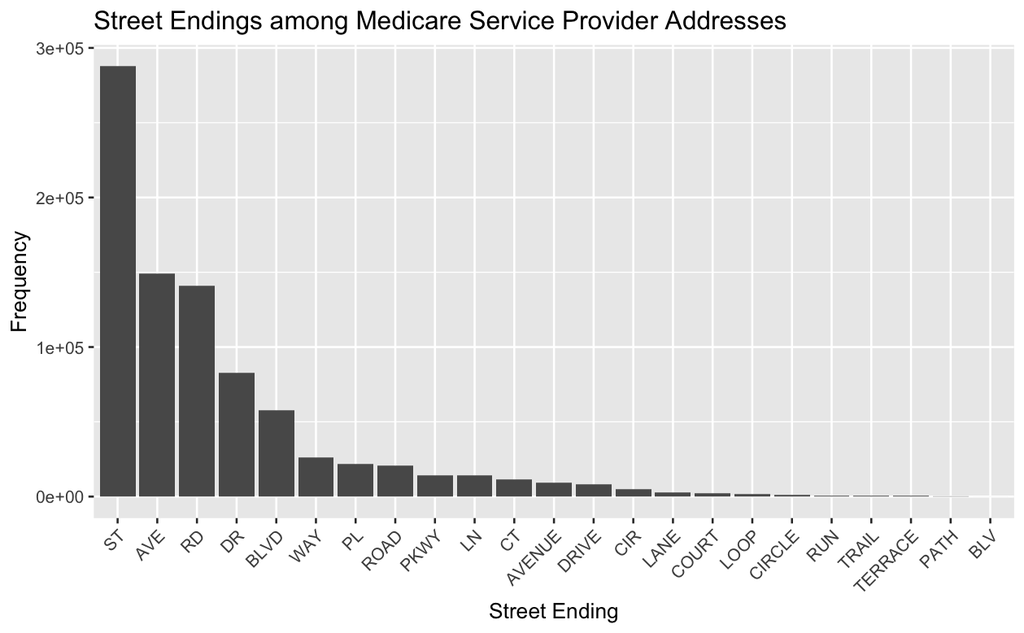

```r
# Bar chart of frequency
RoadNameFrequency %>%
  filter(grepl(pattern = "Medicare", x = source)) %>%
  ggplot(aes(x = reorder(name, desc(count)), y = count)) +
  geom_bar(stat = "identity") +
  theme(axis.text.x = element_text(angle = 45, hjust = 1)) +
  ggtitle("Street Endings among Medicare Service Provider Addresses") +
  xlab("Street Ending") +
  ylab("Frequency")
```

```r
# Frequency table street identifiers
RoadNameFrequency %>%
  filter(grepl(pattern = "Voter", x = source)) %>%
  knitr::kable(align = c('c', 'l'), padding = 0)
```

| name | source | count |
| --- | --- | --- |
| ST | Wake County Voters | 900 |
| RD | Wake County Voters | 744 |
| DR | Wake County Voters | 547 |
| AVE | Wake County Voters | 216 |
| CT | Wake County Voters | 211 |
| DRIVE | Wake County Voters | 206 |
| ROAD | Wake County Voters | 188 |
| PL | Wake County Voters | 152 |
| LN | Wake County Voters | 149 |
| WAY | Wake County Voters | 137 |
| LANE | Wake County Voters | 128 |
| COURT | Wake County Voters | 75 |
| CIRCLE | Wake County Voters | 57 |
| AVENUE | Wake County Voters | 54 |
| CIR | Wake County Voters | 51 |
| BLVD | Wake County Voters | 42 |
| RUN | Wake County Voters | 29 |
| PKWY | Wake County Voters | 28 |
| TRAIL | Wake County Voters | 24 |
| LOOP | Wake County Voters | 12 |
| TERRACE | Wake County Voters | 8 |
| PATH | Wake County Voters | 5 |
| BLV | Wake County Voters | 2 |

```r
RoadNameFrequency %>%
  filter(grepl(pattern = "Medicare", x = source)) %>%
  knitr::kable(align = c('c', 'l'), padding = 0)
```

| name | source | count |
| --- | --- | --- |
| ST | Medicare Service Providers | 287779 |
| AVE | Medicare Service Providers | 149104 |
| RD | Medicare Service Providers | 141133 |
| DR | Medicare Service Providers | 82589 |
| BLVD | Medicare Service Providers | 57942 |
| WAY | Medicare Service Providers | 26011 |
| PL | Medicare Service Providers | 22003 |
| ROAD | Medicare Service Providers | 20974 |
| PKWY | Medicare Service Providers | 14219 |
| LN | Medicare Service Providers | 13962 |
| CT | Medicare Service Providers | 11544 |
| AVENUE | Medicare Service Providers | 9028 |
| DRIVE | Medicare Service Providers | 8202 |
| CIR | Medicare Service Providers | 4767 |
| LANE | Medicare Service Providers | 2534 |
| COURT | Medicare Service Providers | 2135 |
| LOOP | Medicare Service Providers | 1720 |
| CIRCLE | Medicare Service Providers | 1169 |
| RUN | Medicare Service Providers | 838 |
| TRAIL | Medicare Service Providers | 577 |
| TERRACE | Medicare Service Providers | 344 |
| PATH | Medicare Service Providers | 200 |
| BLV | Medicare Service Providers | 16 |

```r
NA
```